# R Notebook

Trying to be more systematic about constrained CCA.

Doing RDA instead of CCA to see what happens

I think I just need one RDA?

## Steps from before

Step 1 – CCA with Station and Depth and Size

Step 2 – CCA with Size, factoring out Station and Depth

Step 3 – CCA with Size, factoring out Station and Depth, removing Free-living microbes

Step 4 - CCA with Size, factoring out Station and Depth, > 5 micron only

Try to get nice looking CCA plots with symbols on each

```r
library(ggvegan)
library(vegan)
library(tidyverse)
library(cowplot)
library(here)
#source(here("RScripts", "InitialProcessing_3.R"))
source(here("RLibraries", "ChesapeakePersonalLibrary.R"))
env1 <- attach(here("RDataFiles", "InitialProcessing_3.RData"))
```

```r
nonSpikes20 <- env1$nonSpikes20
sampleData <- env1$sampleData
```

# Setup

```r
wideASVs <- nonSpikes20 %>%
  mutate(copiesPerLPermm = copiesPerL/Bin_Size) %>%
  #filter(Depth != "Oxy") %>%
  #mutate(copiesPerLPermm = copiesPerL/MassperLiter) %>% # temporary swap out just to see
  select(ID, ASV, copiesPerLPermm) %>%
  pivot_wider(id_cols = ID, names_from = ASV, values_from = copiesPerLPermm) %>%
  column_to_rownames("ID") %>% na.omit()
```

```r
sampleData01 <- sampleData[match(rownames(wideASVs), sampleData$ID),]
```

```r
wideASVs_log <- log(wideASVs + 1)
wideASVs_scaled <- scale(wideASVs_log)
```

## Plot settings

```r
filterSizes <- c(0.2, 1.2, 5, 20, 53, 180, 500)
myGuides <-   guides(shape = guide_legend(ncol = 2), fill = guide_legend(ncol = 2),
         size = guide_legend(ncol = 2),
         color = guide_legend(ncol = 2))

myPlotDetails <- list(
  scale_fill_viridis_d() ,
  scale_shape_manual(values = rep(21:25, 2)),
  scale_color_manual(values = c("green", "blue", "black")) ,
  scale_size(breaks = sqrt(filterSizes),
             labels = filterSizes) ,
  theme_bw(),
  myGuides
)
```

# CCA with everything

but pretty this time

```r
rdaConstrained <- rda(wideASVs_log ~ lat + Depth2 + sqrt(Size_Class), data = sampleData01)
```

```r
rdaConstrained
```

```
Call: rda(formula = wideASVs_log ~ lat + Depth2 + sqrt(Size_Class), data = sampleData01)

                Inertia Proportion Rank
Total         1.090e+04  1.000e+00
Constrained   2.769e+03  2.541e-01    3
Unconstrained 8.128e+03  7.459e-01   71
Inertia is variance

Eigenvalues for constrained axes:
  RDA1   RDA2   RDA3
1606.5  854.0  308.2

Eigenvalues for unconstrained axes:
   PC1    PC2    PC3    PC4    PC5    PC6    PC7    PC8
1641.5 1248.2  859.2  589.7  287.9  259.0  215.3  212.6
(Showing 8 of 71 unconstrained eigenvalues)
```

```r
anova(rdaConstrained)
```

```
Permutation test for rda under reduced model
Permutation: free
Number of permutations: 999

Model: rda(formula = wideASVs_log ~ lat + Depth2 + sqrt(Size_Class), data = sampleData01)
         Df Variance      F Pr(>F)
Model     3   2768.7 8.0618  0.001 ***
Residual 71   8127.9
---
Signif. codes:  0 ‘***’ 0.001 ‘**’ 0.01 ‘*’ 0.05 ‘.’ 0.1 ‘ ’ 1
```

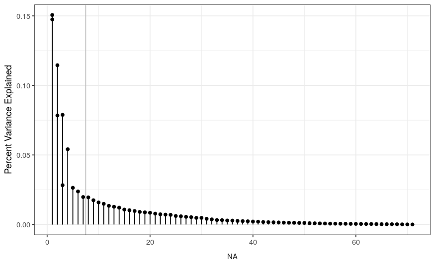

```r
CCA_Eigen_Plot <- function(CCA){
  CCAPctVarPlot <- enframe(c(CCA$CCA$eig/CCA$tot.chi,CCA$CA$eig/CCA$tot.chi), name = "CA", value = "PctVarExplained") %>%
  mutate(CAN = parse_number(CA)) %>%
    mutate(Type = str_remove(CA, "[:digit:].*")) %>%
    mutate(Type = factor(Type, levels = c("CCA", "CA"))) %>%
  ggplot(aes(x = CAN, y = PctVarExplained)) +
  geom_point() +
  geom_segment(aes(x = CAN, xend = CAN, y = 0, yend = PctVarExplained)) +
  labs(y = "Percent Variance Explained", x = NULL) +
  geom_vline(xintercept = 7.5, color = "grey") +
    facet_grid(~Type, scales = "free_x", space = "free_x", switch = "both") +
    #scale_x_continuous(expand = c(0.1,0)) +
  theme_bw() +
  theme(strip.background = element_blank(),
           strip.placement = "outside", legend.position = "none")
CCAPctVarPlot
}

CCA_Eigen_Plot(rdaConstrained)
```

```r
anova(rdaConstrained)
```

```
Permutation test for rda under reduced model
Permutation: free
Number of permutations: 999

Model: rda(formula = wideASVs_log ~ lat + Depth2 + sqrt(Size_Class), data = sampleData01)
         Df Variance      F Pr(>F)
Model     3   2768.7 8.0618  0.001 ***
Residual 71   8127.9
---
Signif. codes:  0 ‘***’ 0.001 ‘**’ 0.01 ‘*’ 0.05 ‘.’ 0.1 ‘ ’ 1
```

```r
mooAnova <- anova(rdaConstrained, by = "margin", permutations = 9999)
mooAnova
```

```
Permutation test for rda under reduced model
Marginal effects of terms
Permutation: free
Number of permutations: 9999

Model: rda(formula = wideASVs_log ~ lat + Depth2 + sqrt(Size_Class), data = sampleData01)
                 Df Variance       F Pr(>F)
lat               1    836.5  7.3071 0.0001 ***
Depth2            1    377.8  3.3001 0.0032 **
sqrt(Size_Class)  1   1538.5 13.4389 0.0001 ***
Residual         71   8127.9
---
Signif. codes:  0 ‘***’ 0.001 ‘**’ 0.01 ‘*’ 0.05 ‘.’ 0.1 ‘ ’ 1
```

```r
mooAnova$Variance/sum(mooAnova$Variance) # proportions explained
```

```
[1] 0.07687926 0.03472126 0.14139355 0.74700592
```

```r
sum(mooAnova$Variance[1:3])/sum(mooAnova$Variance) # same as total variance explained? Very similar
```

```
[1] 0.2529941
```

Lets make this into a nice table Columns are variance?, percent variance explained, F, P And a row added for residual and for total

```r
# note that I'm using a non breaking space in the percent variance variable name
# unicode: 00a0
betaTable <- mooAnova %>% broom::tidy() %>%
  mutate(`% Variance` = Variance/sum(Variance)) %>%
  mutate(term = recode(term, lat = "Latitude", Depth2 = "Depth", `sqrt(Size_Class)` = "√Size Class")) %>%
  select(Term = term, DF = df, Variance, `% Variance`, T = statistic, p = p.value) %>%
    mutate(Variance = format(Variance, digits = 3),
         `% Variance` = format(`% Variance`, digits = 2),
         `T` = if_else(is.na(`T`), "", format(`T`, digits = 2)),
         p = if_else(p < 0.001, "< 0.001", paste0(" ", format(round(p, 3), digits = 1, scientific = FALSE)))
         ) %>%
  flextable() %>%
  align(j = -c(1), align = "right", part = "all") %>%
  bold(i = ~ p < 0.05, j = "p") %>%
  italic(j = "p", part = "header") %>%
  identity()
betaTable
```

| Term | DF | Variance | % Variance | T | p |
| --- | --- | --- | --- | --- | --- |
| Latitude | 1 | 837 | 0.077 | 7.3 | < 0.001 |
| Depth | 1 | 378 | 0.035 | 3.3 | 0.003 |
| √Size Class | 1 | 1538 | 0.141 | 13.4 | < 0.001 |
| Residual | 71 | 8128 | 0.747 |  |  |

```r
betaTable %>% save_as_docx(path = here::here("Tables", "betaTable.docx"))
```

Deal with this later.

## Bookmark

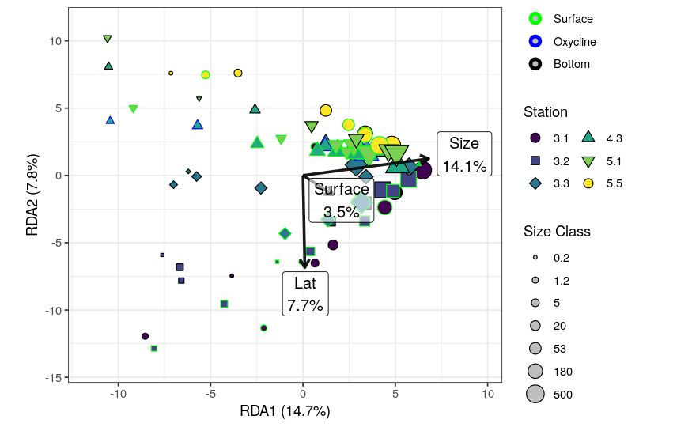

```r
my_fortify_function <- function(ccaConstrained){
  fortify(ccaConstrained) %>% filter(Score %in% c("sites", "biplot")) %>% # not sure what constraints are
  left_join(microbialAbundance, by = c("Label" = "ID"))
}

my_percent_explained <- function(ccaConstrained){
  loc_anova <- anova(ccaConstrained, by = "margin")
  loc_props <- loc_anova$Variance/sum(loc_anova$Variance)
  loc_props_nr <- loc_props[1:(length(loc_props)-1)]
  loc_props_nr
}

My_Constrained_RDA_Plot_Type1 <- function(ccaConstrainedFort, ccaConstrained){
  ccaConstrainedPlot <- ccaConstrainedFort %>%
  filter(Score == "sites") %>%
  mutate(Depth = recode(Depth, `Oxy` = "Oxycline")) %>%
  select(Station, Depth, Size_Class, everything()) %>%
  ggplot(aes(x = RDA1, y = RDA2,
             fill = as.factor(Station),
             shape = as.factor(Station),
             size = sqrt(Size_Class),
             color = as.factor(Depth)
             )) +
 geom_point() +
 coord_fixed(sqrt(ccaConstrained$CCA$eig[2]/ccaConstrained$CCA$eig[1])) +

  geom_segment(aes(x = 0, y = 0, xend  = RDA1 * 7, yend = RDA2 * 7), data = ccaConstrainedFort %>% filter(Score == "biplot"), inherit.aes = FALSE, size = 1, alpha = 0.9, arrow = arrow(length = unit(0.1, "in")), color = "black") +
  #geom_point(aes(x  = CCA1, y = CCA2), data = ccaConstrainedFort %>% filter(Score == "biplot"), inherit.aes = FALSE) +
    labs(x = paste0("RDA1 (", round(ccaConstrained$CCA$eig[1]/ccaConstrained$tot.chi, 3) * 100, "%)"),
       y = paste0("RDA2 (", round(ccaConstrained$CCA$eig[2]/ccaConstrained$tot.chi, 3) * 100, "%)"),
       col = "Depth (Outline Color)",
       fill = "Station",
       shape = "Station",
       size = "Size Class") +
     geom_label(aes(label = Label2, x = RDA1 * 9, y = RDA2 * 9),
            color = "black", fill = "white", alpha = 0.6,
            show.legend = FALSE,
           data = ccaConstrainedFort %>%
             filter(Score == "biplot") %>%
             mutate(Label = recode(Label, lat = "Lat",
                                   `sqrt(Size_Class)` = "Size",
                                   `Depth2Surface` = "Surface"
                                   )) %>%
             mutate(PctExplained = my_percent_explained(ccaConstrained)) %>%
             mutate(Label2 = paste0(Label, "\n", round(PctExplained, 3) * 100, "%"))
             ) +
    lims(x = c(range(ccaConstrainedFort$RDA1)[1] * 1.1, range(ccaConstrainedFort$RDA1)[2] * 1.5), y = range(ccaConstrainedFort$RDA2 * 1.1)) +
  myPlotDetails +
  guides(color = guide_legend(override.aes = list(shape = 21, size = 2, stroke = 2, fill = "gray")),
         shape = guide_legend(override.aes = list(size = 3)),
         size = guide_legend(override.aes = list(shape = 21, color = "black", fill = "gray"))
         )
ccaConstrainedPlot
}

My_Constrained_RDA_Plot_Type1_wFort <- function(ccaConstrained){
  ccaConstrainedFort <- my_fortify_function(ccaConstrained)
  My_Constrained_RDA_Plot_Type1(ccaConstrainedFort, ccaConstrained)
}


My_Constrained_RDA_Plot_Type1_wFort(rdaConstrained)
```

```r
rdaConstrainedFort <- fortify(rdaConstrained) %>% filter(Score %in% c("sites", "biplot")) %>% # not sure what constraints are
 left_join(microbialAbundance, by = c("Label" = "ID"))
```

```r
rdaConstrainedBiplotLabels <- rdaConstrainedFort %>%
  filter(Score == "biplot") %>%
  mutate(Label = recode(Label, lat = "Lat",
                        `sqrt(Size_Class)` = "Size",
                        `Depth2Surface` = "Surface"
  )
  ) %>%
  select(Score:RDA3) %>%
  mutate(PctExplained = mooAnova$Variance[1:3]/sum(mooAnova$Variance)) %>%
  mutate(Label2 = paste0(Label, "\n", round(PctExplained, 3) * 100, "%"))
rdaConstrainedBiplotLabels
```

| Score | Label | RDA1 | RDA2 | RDA3 | PctExplained | Label2 |
| --- | --- | --- | --- | --- | --- | --- |
| biplot | Lat | 0.01464694 | -0.9770402 | -0.2125509 | 0.07687926 | Lat\n7.7% |
| biplot | Surface | 0.23214183 | -0.2054344 | 0.9507402 | 0.03472126 | Surface\n3.5% |
| biplot | Size | 0.97205983 | 0.1776937 | -0.1533774 | 0.14139355 | Size\n14.1% |

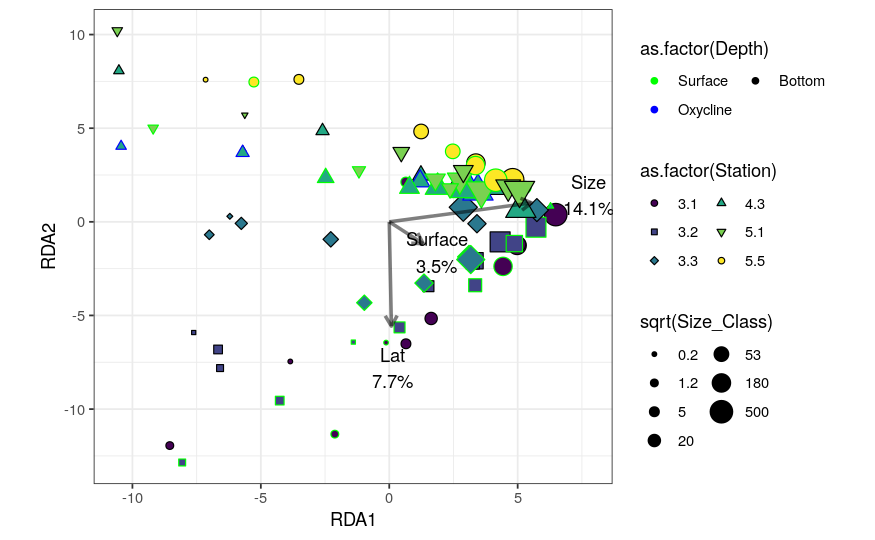

```r
rdaConstrainedPlot <- rdaConstrainedFort %>%
  filter(Score == "sites") %>%
  mutate(Depth = recode(Depth, `Oxy` = "Oxycline")) %>%
  select(Station, Depth, Size_Class, everything()) %>%
  ggplot(aes(x = RDA1, y = RDA2,
             fill = as.factor(Station),
             shape = as.factor(Station),
             size = sqrt(Size_Class),
             color = as.factor(Depth)
             )) +
 geom_point() +
 coord_fixed(sqrt(rdaConstrained$CCA$eig[2]/rdaConstrained$CCA$eig[1])) +
 geom_text(aes(label = Label2, x = RDA1 * 8, y = RDA2 * 8), color = "black", inherit.aes = FALSE,
           data = rdaConstrainedBiplotLabels
             ) +
  geom_segment(aes(x = 0, y = 0, xend  = RDA1 * 5.7, yend = RDA2 * 5.7), data = rdaConstrainedFort %>% filter(Score == "biplot"), inherit.aes = FALSE, size = 1, alpha = 0.5, arrow = arrow(length = unit(0.1, "in"))) +
  #geom_point(aes(x  = CCA1, y = CCA2), data = ccaConstrainedFort %>% filter(Score == "biplot"), inherit.aes = FALSE) +
  myPlotDetails
rdaConstrainedPlot
```

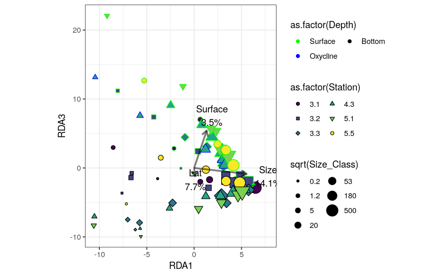

```r
rdaConstrainedPlot13 <- rdaConstrainedFort %>%
  filter(Score == "sites") %>%
  mutate(Depth = recode(Depth, `Oxy` = "Oxycline")) %>%
  select(Station, Depth, Size_Class, everything()) %>%
  ggplot(aes(x = RDA1, y = RDA3,
             fill = as.factor(Station),
             shape = as.factor(Station),
             size = sqrt(Size_Class),
             color = as.factor(Depth)
             )) +
 geom_point() +
 coord_fixed(sqrt(rdaConstrained$CCA$eig[2]/rdaConstrained$CCA$eig[1])) +
 geom_text(aes(label = Label2, x = RDA1 * 8, y = RDA3 * 8), color = "black", inherit.aes = FALSE,
           data = rdaConstrainedBiplotLabels
             ) +
  geom_segment(aes(x = 0, y = 0, xend  = RDA1 * 5.7, yend = RDA3 * 5.7), data = rdaConstrainedFort %>% filter(Score == "biplot"), inherit.aes = FALSE, size = 1, alpha = 0.5, arrow = arrow(length = unit(0.1, "in"))) +
  #geom_point(aes(x  = CCA1, y = CCA2), data = ccaConstrainedFort %>% filter(Score == "biplot"), inherit.aes = FALSE) +
  myPlotDetails
rdaConstrainedPlot13
```

### End of edits

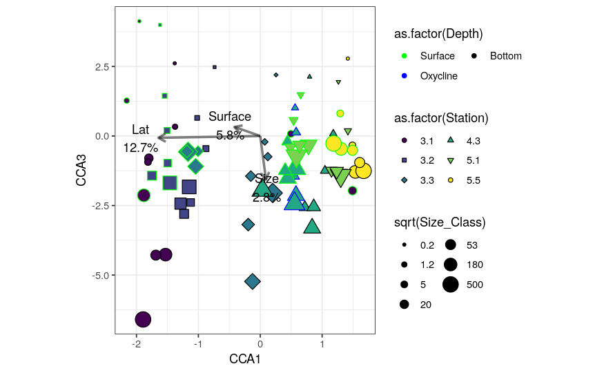

```r
ccaConstrainedPlot13 <- ccaConstrainedFort %>%
  filter(Score == "sites") %>%
  mutate(Depth = recode(Depth, `Oxy` = "Oxycline")) %>%
  select(Station, Depth, Size_Class, everything()) %>%
  ggplot(aes(x = CCA1, y = CCA3,
             fill = as.factor(Station),
             shape = as.factor(Station),
             size = sqrt(Size_Class),
             color = as.factor(Depth)
             )) +
 geom_point() +
 coord_fixed(sqrt(ccaConstrained$CCA$eig[3]/ccaConstrained$CCA$eig[1])) +
 geom_text(aes(label = Label2, x = CCA1 * 2, y = CCA3 * 2), color = "black", inherit.aes = FALSE,
           data = ccaConstrainedBiplotLabels
             ) +
  geom_segment(aes(x = 0, y = 0, xend  = CCA1 * 1.7, yend = CCA3 * 1.7), data = ccaConstrainedFort %>% filter(Score == "biplot"), inherit.aes = FALSE, size = 1, alpha = 0.5, arrow = arrow(length = unit(0.1, "in"))) +
  #geom_point(aes(x  = CCA1, y = CCA2), data = ccaConstrainedFort %>% filter(Score == "biplot"), inherit.aes = FALSE) +
  myPlotDetails
ccaConstrainedPlot13
```

# Constrained ordination with respect to size (all sizes included), conditioned on lat and depth

```r
ccaConditionedAllSizes <- cca(wideASVs_log ~ Condition(Depth2 + lat) + sqrt(Size_Class), data = sampleData01)
```

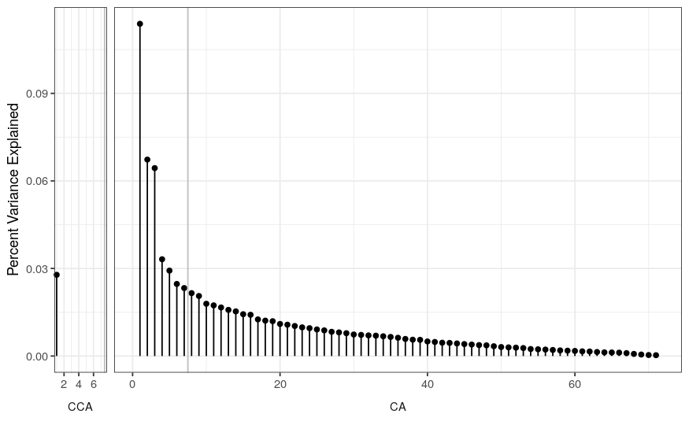

```r
CCA_Eigen_Plot(ccaConditionedAllSizes)
```

```r
paste("Variance Explained", round(ccaConditionedAllSizes$CCA$eig[1]/ccaConditionedAllSizes$tot.chi, 3) * 100, "%")
```

```
[1] "Variance Explained 2.8 %"
```

```r
anova(ccaConditionedAllSizes, permutations = how(nperm = 10^3 - 1))
```

```
Permutation test for cca under reduced model
Permutation: free
Number of permutations: 999

Model: cca(formula = wideASVs_log ~ Condition(Depth2 + lat) + sqrt(Size_Class), data = sampleData01)
         Df ChiSquare      F Pr(>F)
Model     1   0.04254 2.5197  0.001 ***
Residual 71   1.19863
---
Signif. codes:  0 ‘***’ 0.001 ‘**’ 0.01 ‘*’ 0.05 ‘.’ 0.1 ‘ ’ 1
```

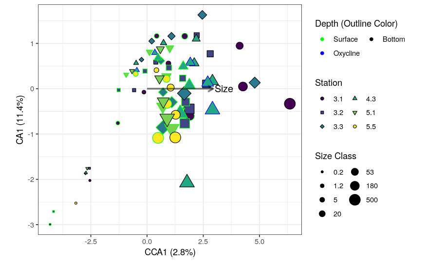

```r
My_Constrained_CCA_Plot <- function(ConditionedCCA){

Fort <- fortify(ConditionedCCA) %>% filter(Score %in% c("sites", "biplot")) %>% # not sure what constraints are
 left_join(microbialAbundance, by = c("Label" = "ID"))

ccaPlot <- Fort %>%
  filter(Score == "sites") %>%
  mutate(Depth = recode(Depth, `Oxy` = "Oxycline")) %>%
  select(Station, Depth, Size_Class, everything()) %>%
  ggplot(aes(x = CCA1, y = CA1,
             fill = as.factor(Station),
             shape = as.factor(Station),
             size = sqrt(Size_Class),
             color = as.factor(Depth)
             )) +
 geom_point() +
 coord_fixed(sqrt(ConditionedCCA$CA$eig[1]/ConditionedCCA$CCA$eig[1])) +
 geom_text(aes(label = Label, x = CCA1 * 3.5, y = CA1 * 3.5), color = "black",
           data = Fort %>%
             filter(Score == "biplot") %>%
             mutate(Label = recode(Label,
                                   `sqrt(Size_Class)` = "Size"

                                   ))
             ) +
  geom_segment(aes(x = 0, y = 0, xend  = CCA1 * 3, yend = CA1 * 3), data = Fort %>% filter(Score == "biplot"), inherit.aes = FALSE, size = 1, alpha = 0.5, arrow = arrow(length = unit(0.1, "in"))) +
  #geom_point(aes(x  = CCA1, y = CCA2), data = ccaConstrainedFort %>% filter(Score == "biplot"), inherit.aes = FALSE) +
  labs(x = paste0("CCA1 (", round(ConditionedCCA$CCA$eig[1]/ConditionedCCA$tot.chi, 3) * 100, "%)"),
       y = paste0("CA1 (", round(ConditionedCCA$CA$eig[1]/ConditionedCCA$tot.chi, 3) * 100, "%)"),
       col = "Depth (Outline Color)",
       fill = "Station",
       shape = "Station",
       size = "Size Class") +
  myPlotDetails
ccaPlot
}

AllSizePlot <- My_Constrained_CCA_Plot(ccaConditionedAllSizes)
AllSizePlot
```

# fortification functions for partial

```r
# my_fortify_function <- function(ccaConstrained){
#   fortify(ccaConstrained) %>% filter(Score %in% c("sites", "biplot")) %>% # not sure what constraints are
#   left_join(microbialAbundance, by = c("Label" = "ID"))
# }
#
# my_percent_explained <- function(ccaConstrained){
#   loc_anova <- anova(ccaConstrained, by = "margin")
#   loc_props <- loc_anova$ChiSquare/sum(loc_anova$ChiSquare)
#   loc_props_nr <- loc_props[1:(length(loc_props)-1)]
#   loc_props_nr
# }

My_Constrained_CCA_Plot_Type2 <- function(ccaConstrainedFort, ccaConstrained){
  ccaConstrainedPlot <- ccaConstrainedFort %>%
  filter(Score == "sites") %>%
  mutate(Depth = recode(Depth, `Oxy` = "Oxycline")) %>%
  select(Station, Depth, Size_Class, everything()) %>%
  ggplot(aes(x = CCA1, y = CA1,
             fill = as.factor(Station),
             shape = as.factor(Station),
             size = sqrt(Size_Class),
             color = as.factor(Depth)
             )) +
 geom_point() +
 coord_fixed(sqrt(ccaConstrained$CA$eig[1]/ccaConstrained$CCA$eig[1])) +
 geom_label(aes(label = Label2, x = CCA1 * 2, y = CA1 * 2), color = "black", fill = "white", alpha = 0.6,
           data = ccaConstrainedFort %>%
             filter(Score == "biplot") %>%
             mutate(Label = recode(Label, lat = "Lat",
                                   `sqrt(Size_Class)` = "Size",
                                   `Depth2Surface` = "Surface"
                                   )) %>%
             mutate(PctExplained = my_percent_explained(ccaConstrained)) %>%
             mutate(Label2 = paste0(Label, "\n", round(PctExplained, 3) * 100, "%"))
             ) +
  geom_segment(aes(x = 0, y = 0, xend  = CCA1 * 1.7, yend = CA1 * 1.7), data = ccaConstrainedFort %>% filter(Score == "biplot"), inherit.aes = FALSE, size = 1, alpha = 0.25, arrow = arrow(length = unit(0.1, "in"))) +
  #geom_point(aes(x  = CCA1, y = CA1), data = ccaConstrainedFort %>% filter(Score == "biplot"), inherit.aes = FALSE) +
    labs(x = paste0("CCA1 (", round(ccaConstrained$CCA$eig[1]/ccaConstrained$tot.chi, 3) * 100, "%)"),
       y = paste0("CA1 (", round(ccaConstrained$CA$eig[1]/ccaConstrained$tot.chi, 3) * 100, "%)"),
       col = "Depth (Outline Color)",
       fill = "Station",
       shape = "Station",
       size = "Size Class") +
  myPlotDetails
ccaConstrainedPlot
}

My_Constrained_CCA_Plot_Type2_wFort <- function(ccaConstrained){
  ccaConstrainedFort <- my_fortify_function(ccaConstrained)
  My_Constrained_CCA_Plot_Type2(ccaConstrainedFort, ccaConstrained)
}
```

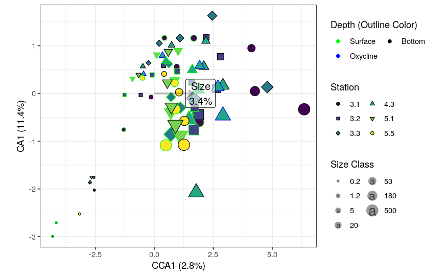

```r
AllSizePlotB <- My_Constrained_CCA_Plot_Type2_wFort(ccaConditionedAllSizes)
AllSizePlotB
```

## Minus free living stuff

```r
sampleData_NoFree <- sampleData01 %>% filter(Size_Class > 1)
wideASVs_log_NoFree <- wideASVs_log[rownames(wideASVs_log) %in% sampleData_NoFree$ID,]
wideASVs_log_NoFree <- wideASVs_log_NoFree[match(sampleData_NoFree$ID, rownames(wideASVs_log_NoFree)),]
# this is silly, I rearanged sample data last time time, but the ASV table this time
```

```r
ccaConditionedNoFree <- cca(wideASVs_log_NoFree ~ Condition(Depth2 + lat) + sqrt(Size_Class), data = sampleData_NoFree)
```

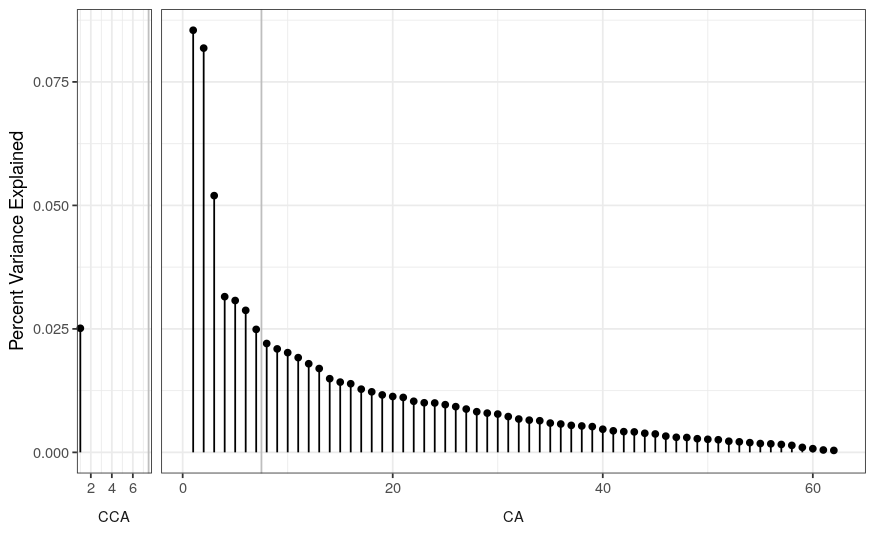

```r
CCA_Eigen_Plot(ccaConditionedNoFree)
```

```r
paste("Variance Explained", round(ccaConditionedNoFree$CCA$eig[1]/ccaConditionedNoFree$tot.chi, 3) * 100, "%")
```

```
[1] "Variance Explained 2.5 %"
```

```r
anova(ccaConditionedNoFree, permutations = how(nperm = 10^3 - 1))
```

```
Permutation test for cca under reduced model
Permutation: free
Number of permutations: 999

Model: cca(formula = wideASVs_log_NoFree ~ Condition(Depth2 + lat) + sqrt(Size_Class), data = sampleData_NoFree)
         Df ChiSquare      F Pr(>F)
Model     1   0.03234 2.0794  0.002 **
Residual 62   0.96414
---
Signif. codes:  0 ‘***’ 0.001 ‘**’ 0.01 ‘*’ 0.05 ‘.’ 0.1 ‘ ’ 1
```

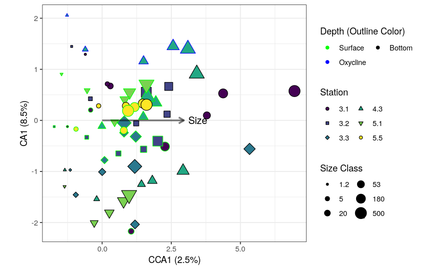

```r
My_Constrained_CCA_Plot(ccaConditionedNoFree)
```

## Minus 1.2 micron stuff

```r
sampleData_NoSmall <- sampleData01 %>% filter(Size_Class > 2)
wideASVs_log_NoSmall <- wideASVs_log[rownames(wideASVs_log) %in% sampleData_NoSmall$ID,]
wideASVs_log_NoSmall <- wideASVs_log_NoSmall[match(sampleData_NoSmall$ID, rownames(wideASVs_log_NoSmall)),]
# this is silly, I rearanged sample data last time time, but the ASV table this time
```

```r
ccaConditionedNoSmall <- cca(wideASVs_log_NoSmall ~ Condition(Depth2 + lat) + sqrt(Size_Class), data = sampleData_NoSmall)
```

```r
paste("Variance Explained", round(ccaConditionedNoSmall$CCA$eig[1]/ccaConditionedNoSmall$tot.chi, 3) * 100, "%")
```

```
[1] "Variance Explained 2.6 %"
```

```r
anova(ccaConditionedNoSmall, permutations = how(nperm = 10^3 - 1))
```

```
Permutation test for cca under reduced model
Permutation: free
Number of permutations: 999

Model: cca(formula = wideASVs_log_NoSmall ~ Condition(Depth2 + lat) + sqrt(Size_Class), data = sampleData_NoSmall)
         Df ChiSquare      F Pr(>F)
Model     1   0.03376 1.8294  0.004 **
Residual 53   0.97816
---
Signif. codes:  0 ‘***’ 0.001 ‘**’ 0.01 ‘*’ 0.05 ‘.’ 0.1 ‘ ’ 1
```

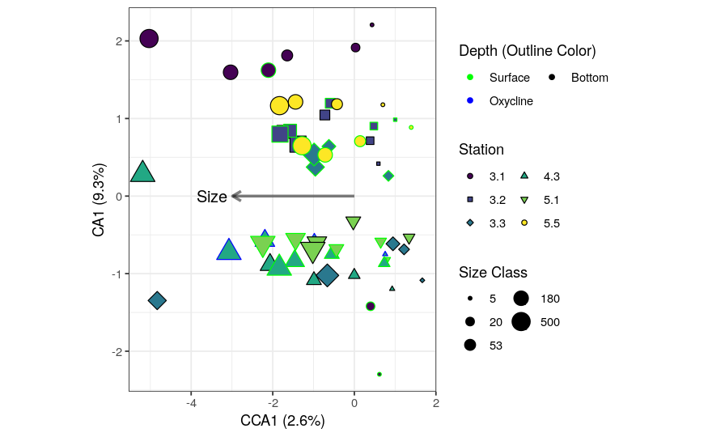

```r
My_Constrained_CCA_Plot(ccaConditionedNoSmall)
```

Hahaha. Ok, now size is a factor, as I expected. Maybe I was just underpowered with the surface only stuff? Or the non-effect is only in the surface?

## Minus 1.2 micron stuff surface only

```r
sampleData_NoSmall <- sampleData01 %>% filter(Size_Class > 2) %>% filter(Depth == "Surface")
wideASVs_log_NoSmall <- wideASVs_log[rownames(wideASVs_log) %in% sampleData_NoSmall$ID,]
wideASVs_log_NoSmall <- wideASVs_log_NoSmall[match(sampleData_NoSmall$ID, rownames(wideASVs_log_NoSmall)),]
# this is silly, I rearanged sample data last time time, but the ASV table this time
```

```r
ccaConditionedNoSmall <- cca(wideASVs_log_NoSmall ~ Condition(lat) + sqrt(Size_Class), data = sampleData_NoSmall)
```

```r
paste("Variance Explained", round(ccaConditionedNoSmall$CCA$eig[1]/ccaConditionedNoSmall$tot.chi, 3) * 100, "%")
```

```
[1] "Variance Explained 4.7 %"
```

```r
anova(ccaConditionedNoSmall, permutations = how(nperm = 10^3 - 1))
```

```
Permutation test for cca under reduced model
Permutation: free
Number of permutations: 999

Model: cca(formula = wideASVs_log_NoSmall ~ Condition(lat) + sqrt(Size_Class), data = sampleData_NoSmall)
         Df ChiSquare     F Pr(>F)
Model     1   0.05115 1.366  0.057 .
Residual 22   0.82381
---
Signif. codes:  0 ‘***’ 0.001 ‘**’ 0.01 ‘*’ 0.05 ‘.’ 0.1 ‘ ’ 1
```

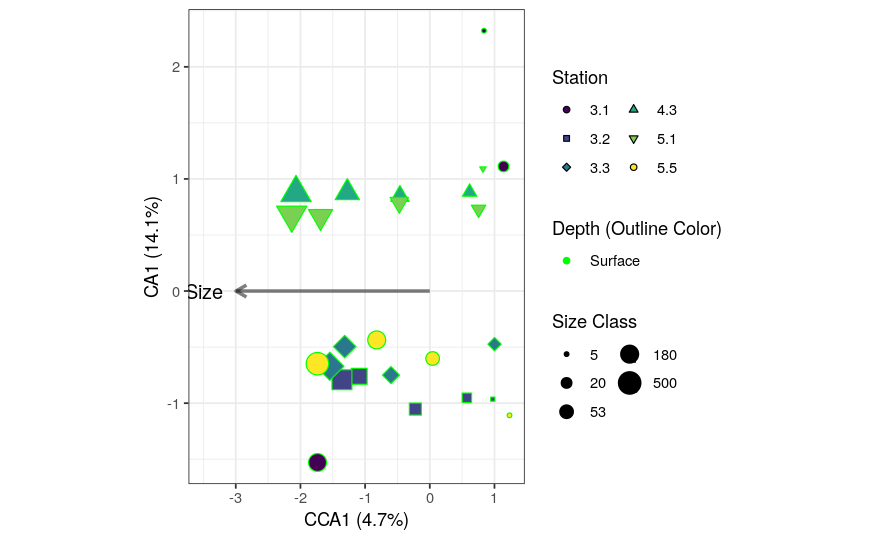

```r
My_Constrained_CCA_Plot(ccaConditionedNoSmall)
```

## Minus 1.2 micron stuff bottom only

```r
sampleData_NoSmall <- sampleData01 %>% filter(Size_Class > 2) %>% filter(Depth == "Bottom")
wideASVs_log_NoSmall <- wideASVs_log[rownames(wideASVs_log) %in% sampleData_NoSmall$ID,]
wideASVs_log_NoSmall <- wideASVs_log_NoSmall[match(sampleData_NoSmall$ID, rownames(wideASVs_log_NoSmall)),]
# this is silly, I rearanged sample data last time time, but the ASV table this time
```

```r
ccaConditionedNoSmall <- cca(wideASVs_log_NoSmall ~ Condition(lat) + sqrt(Size_Class), data = sampleData_NoSmall)
```

```r
paste("Variance Explained", round(ccaConditionedNoSmall$CCA$eig[1]/ccaConditionedNoSmall$tot.chi, 3) * 100, "%")
```

```
[1] "Variance Explained 3.6 %"
```

```r
anova(ccaConditionedNoSmall, permutations = how(nperm = 10^3 - 1))
```

```
Permutation test for cca under reduced model
Permutation: free
Number of permutations: 999

Model: cca(formula = wideASVs_log_NoSmall ~ Condition(lat) + sqrt(Size_Class), data = sampleData_NoSmall)
         Df ChiSquare      F Pr(>F)
Model     1   0.04981 1.1725  0.134
Residual 25   1.06198
```

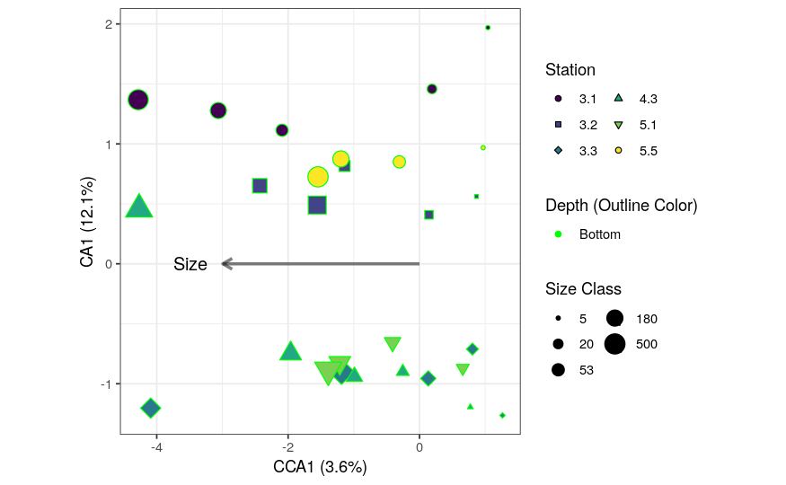

```r
My_Constrained_CCA_Plot(ccaConditionedNoSmall)
```

Too narrow. I’m calling it, size does matter.

# Lat and Depth Only

One more thing, I need to know the percent variance explained by just depth and latitude, so that I can show how much extra mileage size gets me.

```r
ccaConstrainedNoSize <- cca(wideASVs_log ~ lat + Depth2, data = sampleData01)
```

```r
ccaConstrainedNoSize
```

```
Call: cca(formula = wideASVs_log ~ lat + Depth2, data = sampleData01)

              Inertia Proportion Rank
Total          1.5285     1.0000
Constrained    0.2874     0.1880    2
Unconstrained  1.2412     0.8120   72
Inertia is scaled Chi-square

Eigenvalues for constrained axes:
   CCA1    CCA2
0.20209 0.08526

Eigenvalues for unconstrained axes:
    CA1     CA2     CA3     CA4     CA5     CA6     CA7     CA8
0.18977 0.10289 0.09995 0.05506 0.04976 0.03999 0.03699 0.03305
(Showing 8 of 72 unconstrained eigenvalues)
```

```r
anova(ccaConstrainedNoSize, by = "margin")
```

```
Permutation test for cca under reduced model
Marginal effects of terms
Permutation: free
Number of permutations: 999

Model: cca(formula = wideASVs_log ~ lat + Depth2, data = sampleData01)
         Df ChiSquare       F Pr(>F)
lat       1   0.19512 11.3188  0.001 ***
Depth2    1   0.09272  5.3787  0.001 ***
Residual 72   1.24116
---
Signif. codes:  0 ‘***’ 0.001 ‘**’ 0.01 ‘*’ 0.05 ‘.’ 0.1 ‘ ’ 1
```

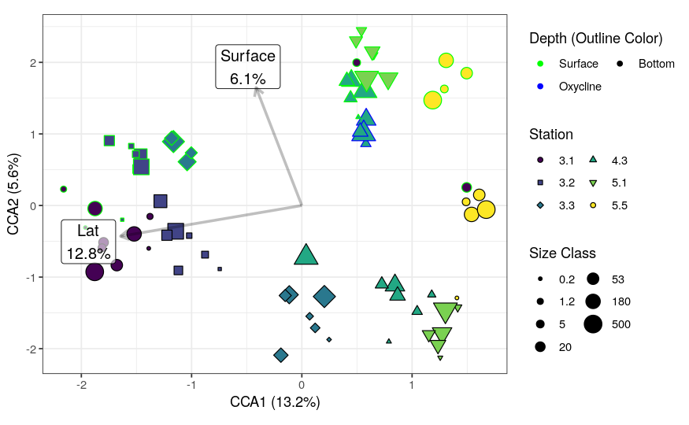

```r
DepthLatPlot <- My_Constrained_CCA_Plot_Type1_wFort(ccaConstrainedNoSize)
DepthLatPlot
```